# project2_testfile

Here's some stuff I threw together over the weekend, I'll show what I got, what numerical and computational stuff I've done with it.

## Background

It looks like were going to be using a system of equations based on work by lokta and volterra. These are basically just logistic functions (there's an example of one in the first chapter of the book, and shows how screwy they are to solve directly).

If you want a basic intro, here's a good video:

https://www.youtube.com/watch?v=aY6zYCuRWr0

## Example

Here is an equation with constants I picked up somewhere. Let's pretend f is foxes, and h is hares.

$\vec{x'} = \begin{pmatrix} \alpha & -\beta f \\ \delta h & -\epsilon \end{pmatrix} \vec{x}$

$\vec{x} = \begin{pmatrix} h \\ f \end{pmatrix}$

$\alpha = .01 \\ \beta = .01 \\ \delta = .01 \\ \epsilon = .01$

These constants give a really nice integer equilibrium solution; by selecting either line (I'll do the first). Letting rate of change be 0:

$\begin{align}0 &= h(\alpha - \beta f) \\ &=\alpha - \beta f \end{align}$

$f= \frac{\alpha}{\beta} \\ r=\frac{\epsilon}{\delta}$

I'll go ahead and plot it below in the way I already know how to plot stuff in python, but I'd rather do something like a slope field, might need help there.

https://homepages.bluffton.edu/~nesterd/java/slopefields.html?flags=2&SYS=t,r,f&dxdt=r*(0.4-0.05f)&dydt=f*(.005r-0.2)&x=0,100,15&y=0,16,15&method=rk4&h=0.1&pts1=%5B40,8%5D,%5B39,7%5D,%5B60,1%5D

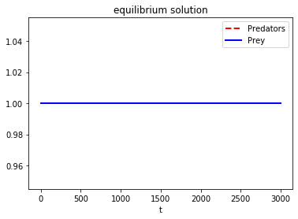

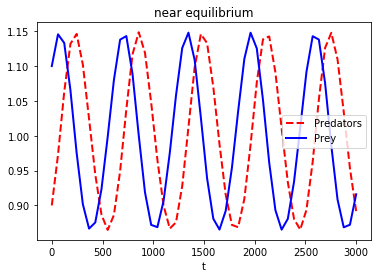

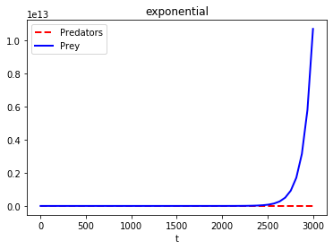

```python
import numpy as np
from scipy.integrate import odeint
import matplotlib.pyplot as plt

def f(s,t):
    a = .01
    b = .01
    d = .01
    e = .01
    fox = s[0]
    hare = s[1]
    dharedt = hare * (a - (b * fox))
    dfoxdt = fox * (((d * hare) - e))
    return [dfoxdt, dharedt]

t = np.linspace(0,3000)

s0=[1,1]  # prey, predator
s1=[0.9,1.1]
s2=[0,1]

sa = odeint(f,s0,t)
sb = odeint(f,s1,t)
sc = odeint(f,s2,t)

plt.plot(t,sa[:,0],'r--', linewidth=2.0)
plt.plot(t,sa[:,1],'b-', linewidth=2.0)
plt.title("equilibrium solution")
plt.xlabel("t")
plt.legend(["Predators","Prey"])
plt.show()

plt.plot(t,sb[:,0],'r--', linewidth=2.0)
plt.plot(t,sb[:,1],'b-', linewidth=2.0)
plt.title("near equilibrium")
plt.xlabel("t")
plt.legend(["Predators","Prey"])
plt.show()

plt.plot(t,sc[:,0],'r--', linewidth=2.0)
plt.plot(t,sc[:,1],'b-', linewidth=2.0)
plt.title("exponential")
plt.xlabel("t")
plt.legend(["Predators","Prey"])
plt.show()
```

## Questions from here

What else do you think we should ask the class?

Thanks for reading, let me know what you think and what you guys have found!